# PeakScanner_peakFilter_V3_5_1: 20220404_MDH_kita-T1_mpompeg_PLATE01

Kita-T1-atto — excluded 183, 210

Last compiled on: 2023-08-03

## PARAMETERS

### File locations, names and wt fragment size and channel to be used

#### Setting the channel to be analyzed

!OBS! this handles single channel runs only (STD (ROX) + 1 sample dye)

**blue / FAM** channel = “B”  
**green / HEX** channel = “G”  
**yellow / atto** channel = “Y”  
**red channel (ROX - STANDARD)**

```r
#IF this is "TRUE" then an HTML report will be created automatically; if it´s "FALSE" no report will be created automatically; using "Knit" button in RStudio will do the same.
KNITreport <- TRUE

#set the input/output directories
dir_input <- "./input/"
dir_output <- "./output/"

#channel of the sample dye ("B" blue, "G" green, "Y" yellow)
channel <- "Y"

#set the file name
fileName <- "20220404_MDH_kita-T1vsT2_mpompeg_PLATE01.txt"

#set the size of the WT
WTsize <- 211
```

### More parameters

These **parameters should not be changed** in STD conditions. **IF changed, changes should be documented**.

```r
#the margin of how wide the size range should be around the "wt size" (should not be 0.5 as that will be halfway to the next fragement size and is more likely to include false positives.
WTsizeMargin <- 0.4

#if there are any peaks that need to be ignored as they are clearly artifacts and far enough away from WT peaks (>=2 bp) their size can be added to the list here ( e.g. c(150) igonres any peak with size of 150 bp; c(150, 120) - peaks with 150 or 120 bp are ignored)
IgnorePeakSize <- c(183, 210) # set to -1000 if nothing should be ignored, as there will not be any peaks with size -1000.

#SET PARAMETERS FOR FILTERING
#smallSizeCutOff is used to remove PCR products that are too small to be true products (e.g. primer dimers etc); even though the data will also be filtered by WTsize ¨+/- size_span, this parameter makes sure, a large size span does not accidentially include the too small products.
smallSizeCutOff <- 100

#smallPeakHeightCutOFF is used to set a minium hight of genuine peaks
smallPeakHeightCutOff <- 800
#manuaPeakHeightCutOFF; when true the manually set value is used, when false a dataset with runs of standard only (no sammple) has to be provided; this will be used to determine the threshold based on experimental data
manualPeakHeightCutOFF <- TRUE
#adjust % in line 190ish to same as set here
smallPeakHeightCutOff_quantile <- 0.99

#set the span around the size of the WT, everything outside that range will be removed
size_span <- 50
```

## LIBRARIES

```r
#loading libraries
#if (!require("plyr")){
#    install.packages("plyr")
#    require("plyr")}
if (!require("stringr")){
    install.packages("stringr")
    require("stringr")}
if (!require("tidyverse")){
    install.packages("tidyverse")
    require("tidyverse")}
if (!require("viridis")){
    install.packages("viridis")
    require("viridis")}
if (!require("plotly")){
    install.packages("plotly")
    require("plotly")}
```

## Reading of data files

- results exported form peak scanner
- plate layout of sample names
- plate layout of sample types

```
## [1] "READ peak scanner data file: ./input/20220404_MDH_kita-T1vsT2_mpompeg_PLATE01.txt"
```

```
## [1] "READ sample types layout file: ./input/ 20220404_MDH_kita-T1vsT2_mpompeg_PLATE01_PLATE_LAYOUT.txt"
```

## Determination of *noise* peaks

- Noise are peaks that appear in “blank” sample runs (runs with the size standard but no sample). Every sample peak that is not higher than the *noise* peak(s) is most likely noise and needs to be disregarded in further analysis.
- On standard plate layouts 8 wells without samples are present and the script will use the data from those wells to determine *noise*.
- If a plate does not contain “blank” wells the initial parameter (smallPeakHeightCutOff ) will be used

```
## [1] "!OBS! Minimal PeakHightCutoff was not selected (manualPeakHeightCutOFF = TRUE); the set parameter (smallPeakHeightCutOff) used is: 800"
```

## Filtering and processing of data

Removing peaks with

- size = NA
- Quality != “Pass” (Quality is a parameter from peak finder)

Flagging peaks as “passed filter = TRUE” if

```
## [1] "WELLS with too LOW QUALITY (according to PeakScanner) - and removed from analysis:"
```

```
## character(0)
```

```
## [1] "---------------"
```

```
## [1] "Peak sizes to ignore :"
```

```
## [1] 183 210
```

```
## [1] "Peaks with this size: 151"
```

```
## [1] "Wells"
```

```
##  [1] "A01" "A02" "A03" "A04" "A05" "A06" "A07" "A08" "A09" "A10" "A11" "B01" "B02" "B03"
## [15] "B04" "B05" "B06" "B07" "B08" "B09" "B10" "B11" "B12" "C01" "C02" "C04" "C05" "C06"
## [29] "C07" "C08" "C09" "C10" "C11" "C12" "D01" "D02" "D03" "D04" "D05" "D06" "D07" "D08"
## [43] "D09" "D10" "D11" "E01" "E02" "E03" "E04" "E05" "E07" "E08" "E09" "E10" "E11" "F02"
## [57] "F03" "F04" "F05" "F09" "F10" "F11" "G01" "G02" "G03" "G04" "G05" "G06" "G07" "G09"
## [71] "G10" "G11" "G12" "H01" "H02" "H03" "H04" "H05" "H06" "H07" "H08" "H09" "H10" "H11"
```

```
## [1] "---------------"
```

```
## [1] "Samples that had no peaks that passed the filter:"
```

```
##  [1] "A08_A08.fsa" "A12_A12.fsa" "B08_B08.fsa" "B09_B09.fsa" "B12_B12.fsa" "C05_C05.fsa"
##  [7] "C12_C12.fsa" "D12_D12.fsa" "E06_E06.fsa" "E12_E12.fsa" "F06_F06.fsa" "F07_F07.fsa"
## [13] "F08_F08.fsa" "F11_F11.fsa" "F12_F12.fsa" "G08_G08.fsa" "G12_G12.fsa" "H12_H12.fsa"
```

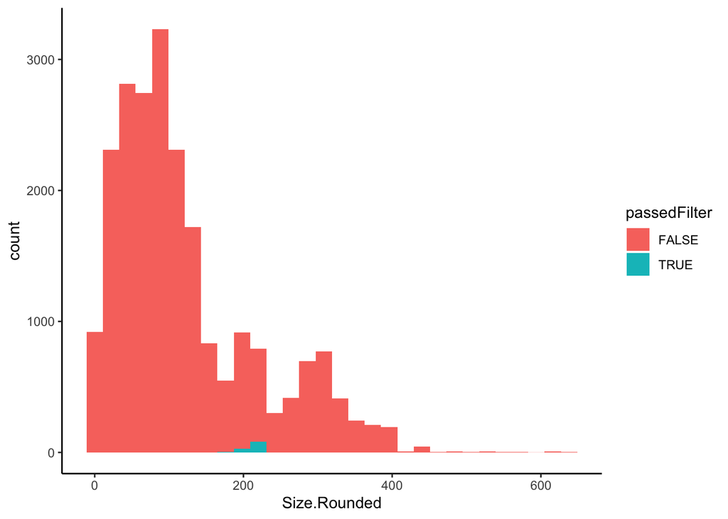

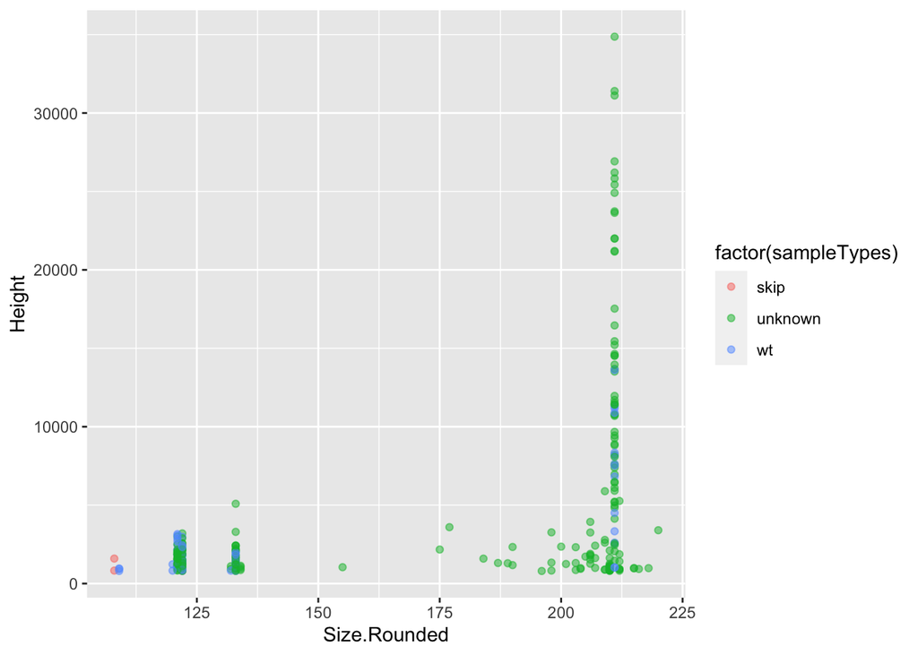

## Comparing peak areas with peak heights

These peaks passed the filter and will be used for analysis. The plots should be mostly linear. If “Area.in.Point/BP” increases while “Height” doesn´t the dataset contains peaks that are too high.

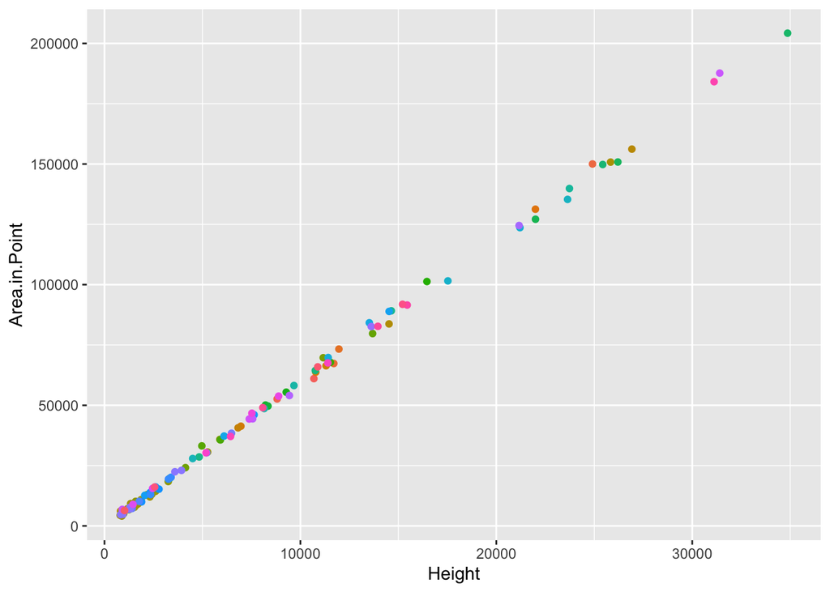

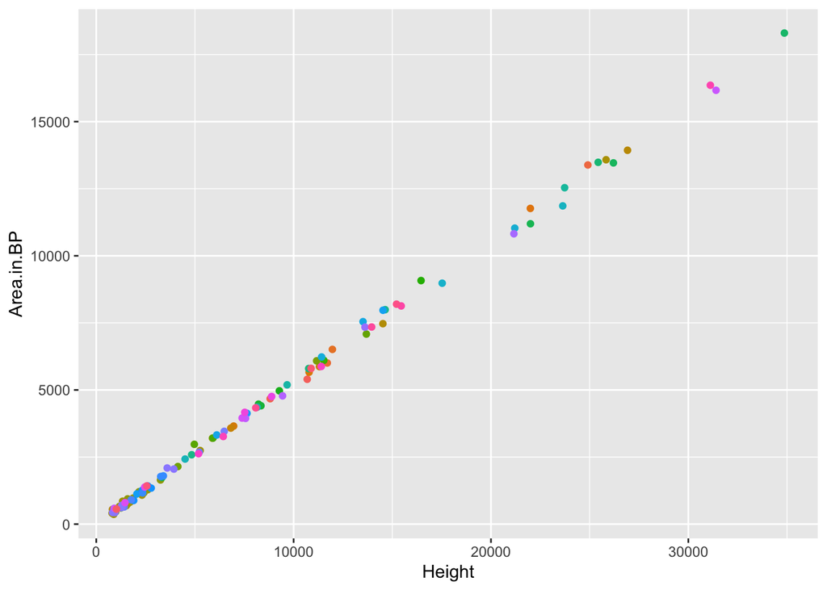

## Determining relative peak areas and total peak area per sample

Per sample calculating on filtered data:  
* Area.in.BP.RelToMax: peak areas relative to largest peak (area/max(area)); max = 1  
* Area.in.BP.RelToSum: peak areas relative to total peak area (area / sum(area)); sum = 1  
* Area.in.BP.Sum: total peak area

## Estimation of the size-range of WT peaks

As fragment sizes are determined by calibration via a size standard, sizes are numbers with decimals.  
Therefore, sizes must be rounded to full numbers to be able to calculate InDelSizes. However, in cases where wt fragements can be rounded up or down in different samples (e.g. 211.4 and 211.5) this can cause a serious problem of wt-peak detection.

Here the size range of wt peaks of wt-samples is determined:

- the highest peak must have a rounded fragment size of wt-size +/- 1 bp
  - make sure to check that wt-samples look good if there are problems here
- get the min and max fragment sizes
- expand the size range by 25%
- if more than one peak is within the wt-peak range, the peak closest to the median of wt peak sizes will be assigned as wt peak in that well and marked TRUE in

```
## [1] "WT peaks in WT samples found: 15 list of fragment sizes"
```

```
##  [1] 210.9112 210.9549 210.9112 210.9276 210.9674 210.9493 210.9819 210.9974 210.9663
## [10] 210.9589 210.9674 210.9308 210.9549 210.9589 210.9965
```

```
## [1] "WT samples with largest peak of rounded length = WT fragment length"
```

```
##  [1] "A10" "A11" "B10" "B11" "C10" "C11" "D10" "D11" "E10" "E11" "F10" "G10" "G11" "H10"
## [15] "H11"
```

```
## [1] "WT samples with largest peak of rounded length = WT fragment length - 1"
```

```
## character(0)
```

```
## [1] "WT samples with largest peak of rounded length = WT fragment length + 1"
```

```
## character(0)
```

```
## [1] "median of WT sizes: 210.9589  and the resulting size correction factor: 0.0411000000000001"
```

```
## [1] "After size correction, the median of the wt peak sizes is: 211"
```

```
## [1] "The WT samples have fragment sizes between  210.9523 bp and  211.0385 bp. The WTsizeMargin is:+/- 0.4"
```

```
## [1] "Unknown fragments with sizes between 210.6  and  211.4 will be considered as WT fragments."
```

```
## [1] "Number of samples that after WT assignemnts have two peaks considered beeing WT peaks: 0"
```

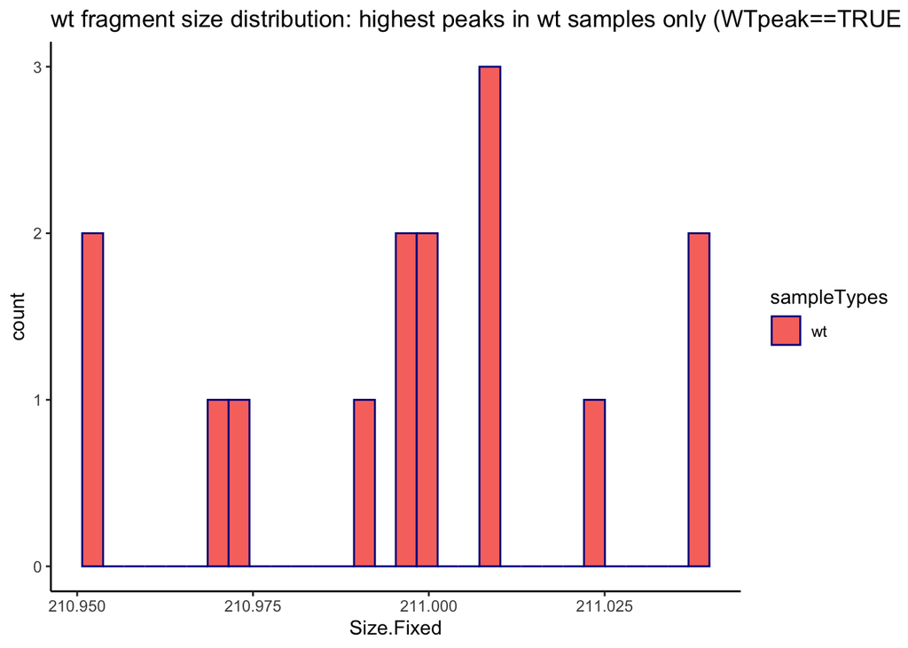

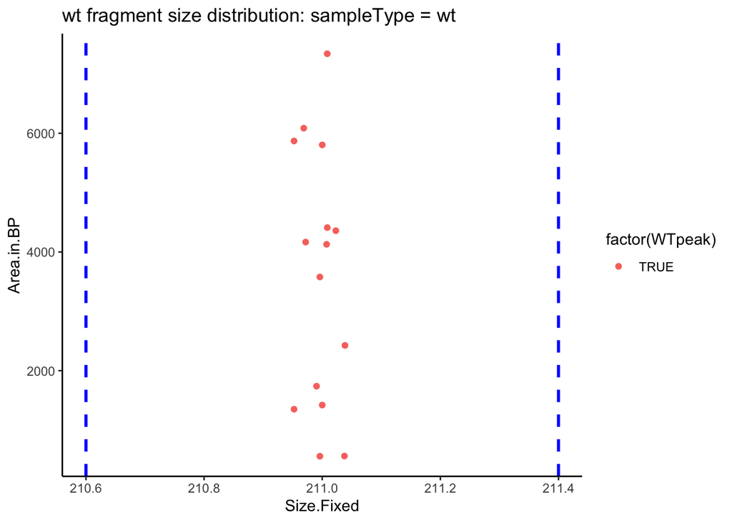

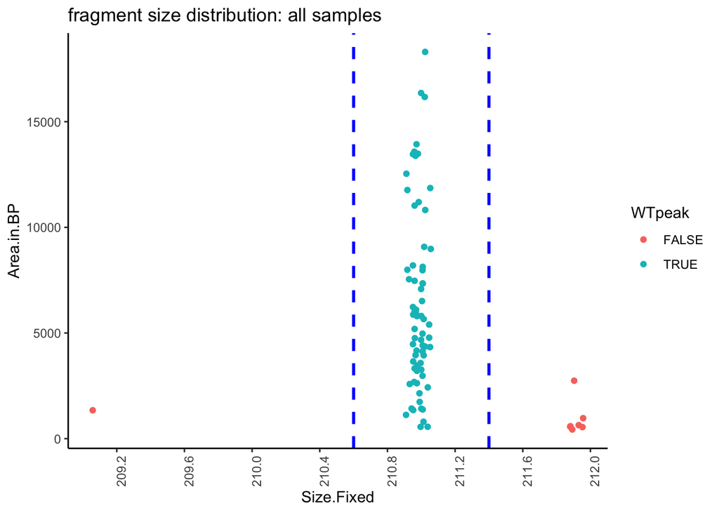

## Calculating the sizes of the InDels

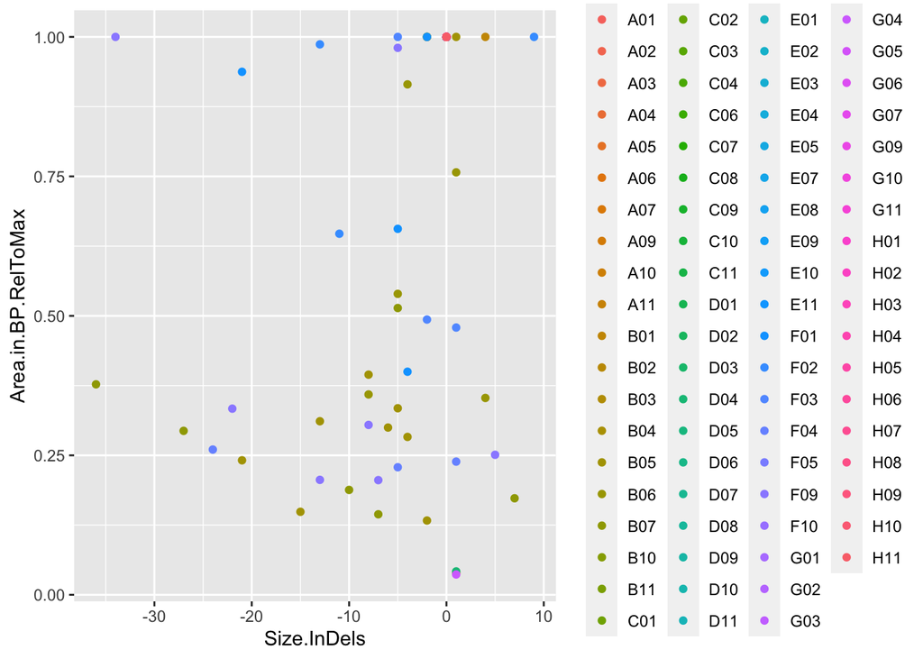

## Summarising data & plotting

```
## [1] "Samples that were removed from analysis by filtering"
```

```
##  [1] "A08" "A12" "B08" "B09" "B12" "C05" "C12" "D12" "E06" "E12" "F06" "F07" "F08" "F11"
## [15] "F12" "G08" "G12" "H12"
```

```
## [1] "All relative peak areas added up to 1 for each sample"
```

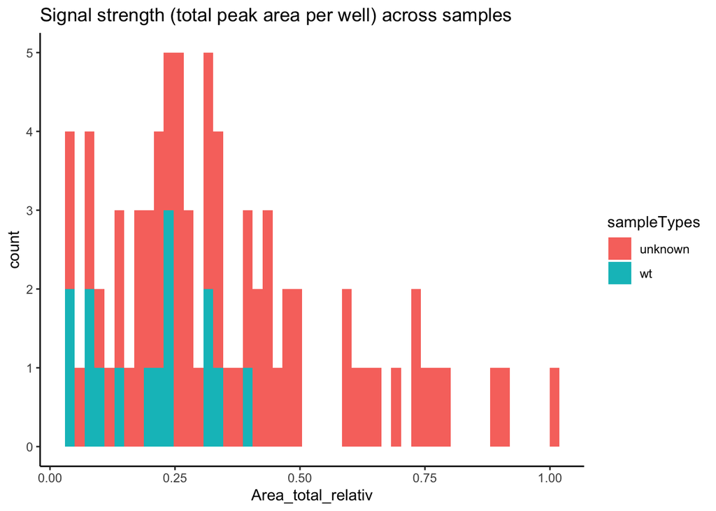

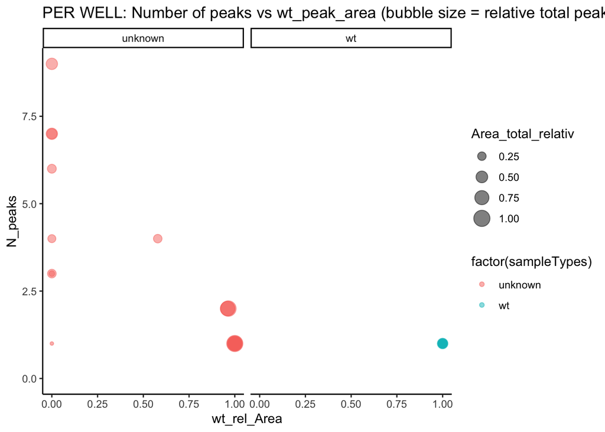

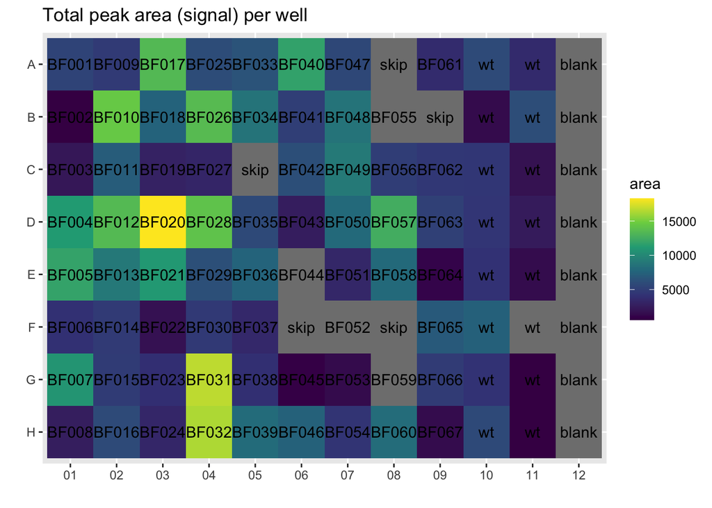

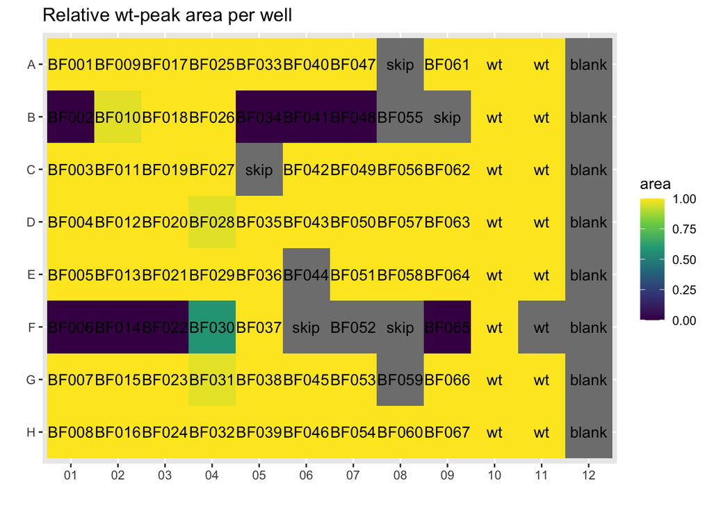

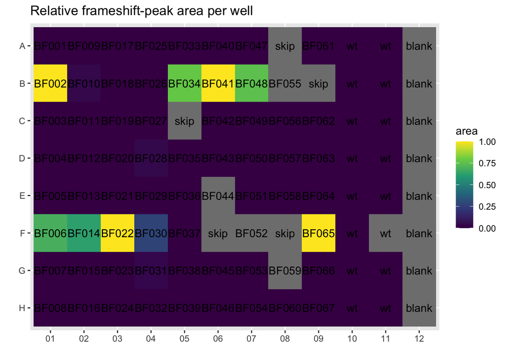

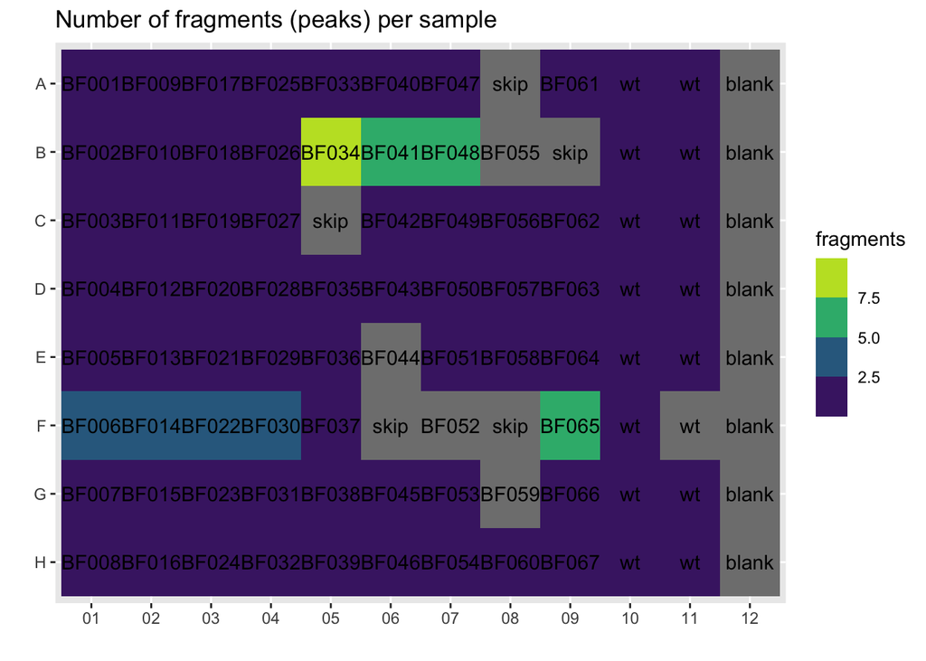

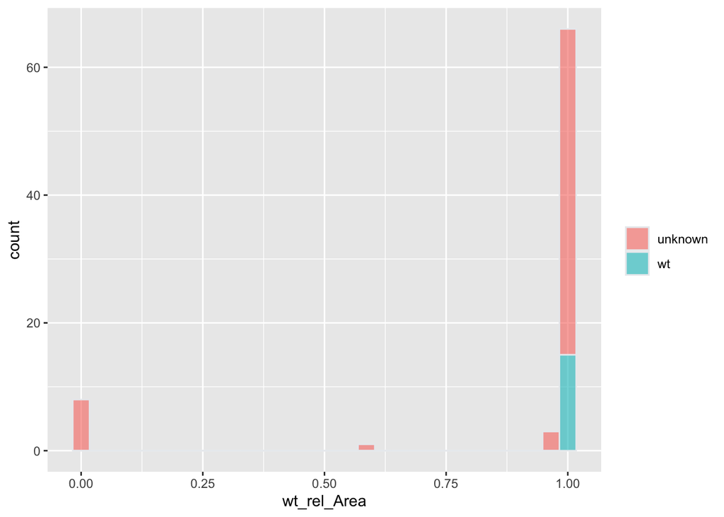

```
## [1] "--------------"
```

```
## [1] "Saved output as file  20220404_MDH_kita-T1vsT2_mpompeg_PLATE01_RESULTS_T1_atto.txt"
```

```
## [1] "@ /Users/endmu284/Documents/Obesity Eugenia/Kita/FLA_repository/output/"
```

#Rough quantification of “bad” wt sampels and putative negative controls * cutoff for a wild type peak to be considered beeing solid (the allele beeing wt): 0.8

```
## [1] "wt samples with too small relative peak area (< 0.8) for wt peak:"
```

```
## [1] NA
```

```
## [1] "potential negative controls (injected samples with peak area of wt fragment size and relative wt peak area > 0.8)"
```

```
##  [1] "A01" "A02" "A03" "A04" "A05" "A06" "A07" NA    "A09" NA    "B02" "B03" "B04" NA
## [15] NA    NA    "C01" "C02" "C03" "C04" NA    "C06" "C07" "C08" "C09" NA    "D01" "D02"
## [29] "D03" "D04" "D05" "D06" "D07" "D08" "D09" NA    "E01" "E02" "E03" "E04" "E05" NA
## [43] "E07" "E08" "E09" NA    "F05" NA    NA    NA    NA    "G01" "G02" "G03" "G04" "G05"
## [57] "G06" "G07" NA    "G09" NA    "H01" "H02" "H03" "H04" "H05" "H06" "H07" "H08" "H09"
## [71] NA
```

### Plotting InDel-centric data in more detail

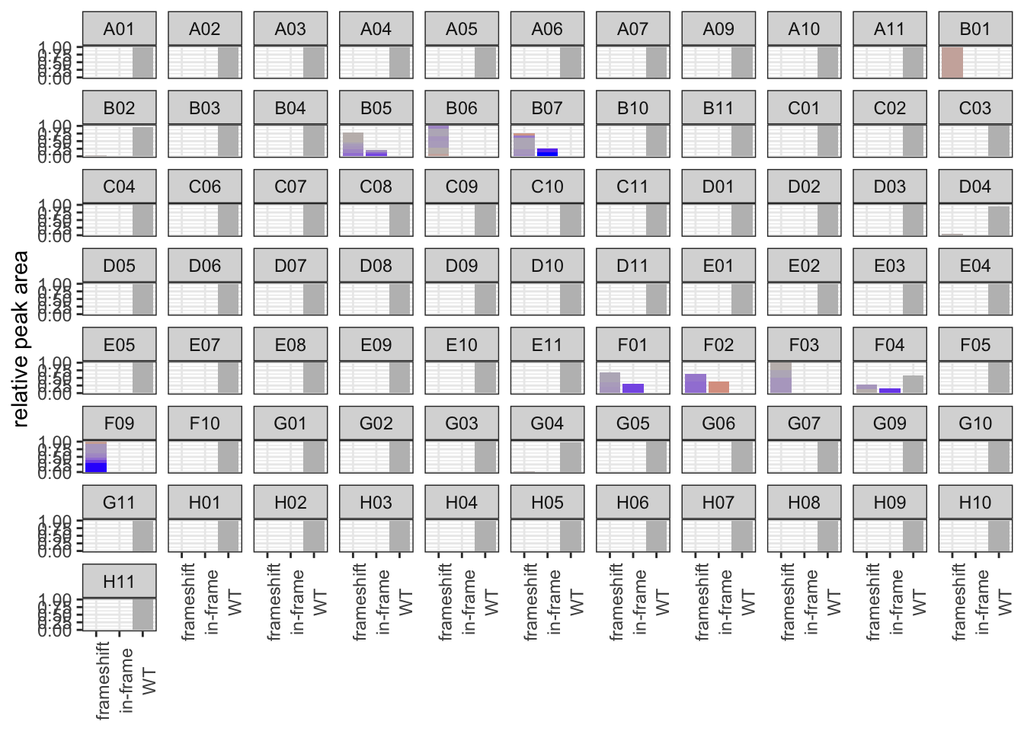

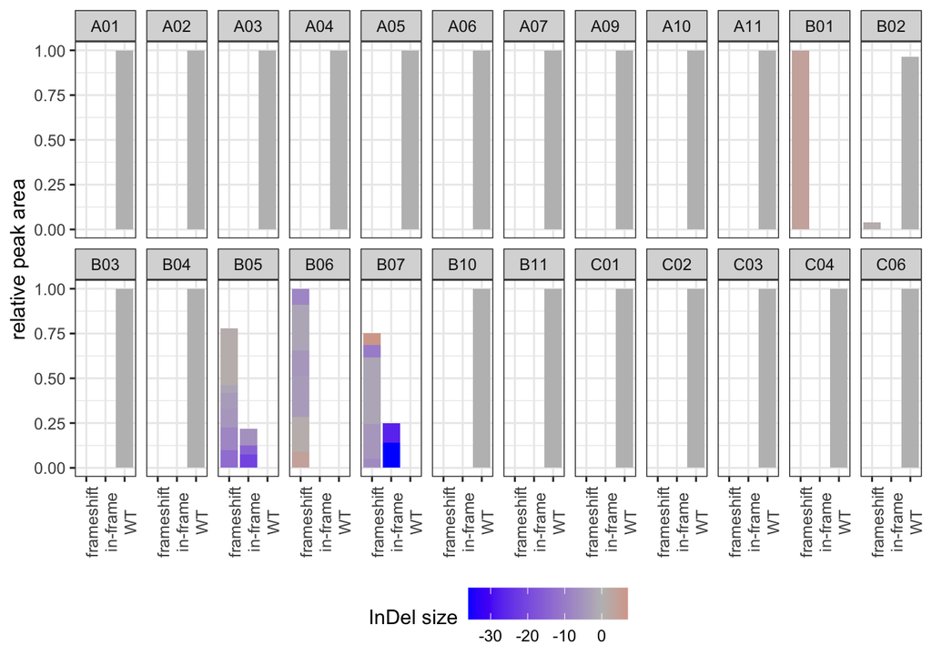

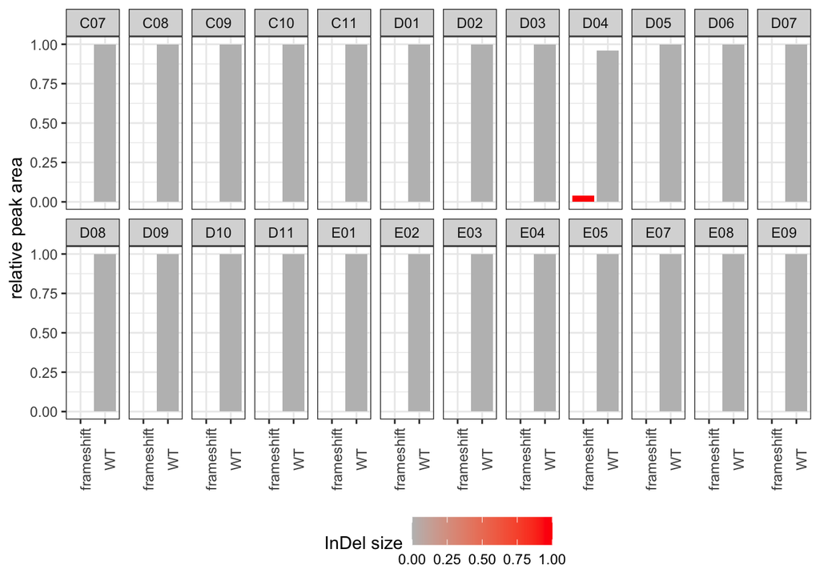

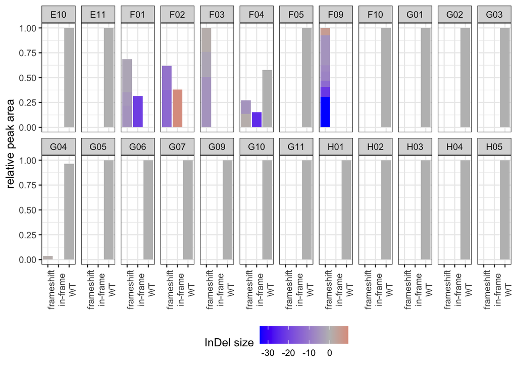

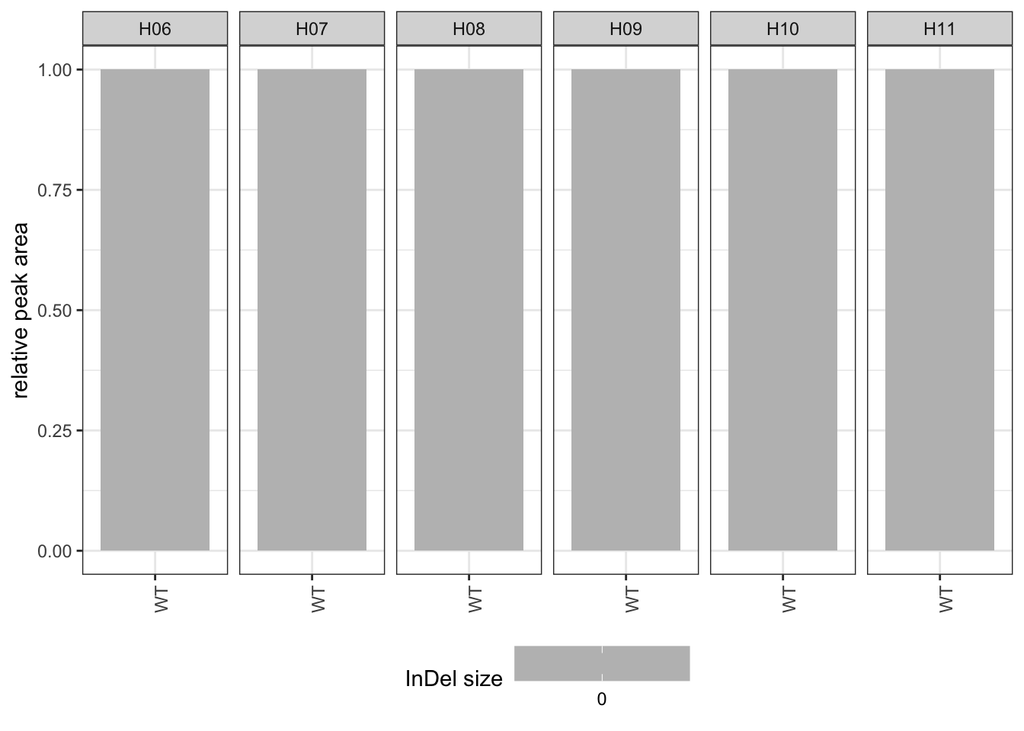